# Tutorial Part II — R goes Spatial

### Queries on raster values

You can easily access the cell information of the raster via `values()`

```r
## convert ras_bio_asc_01 to degree Celsius units (divide by 10)
range(values(ras_bio_asc_01), na.rm = TRUE)
```

```
## [1]  63 278
```

Visualise range of the values with a simple boxplot (see course 1 R Intro).

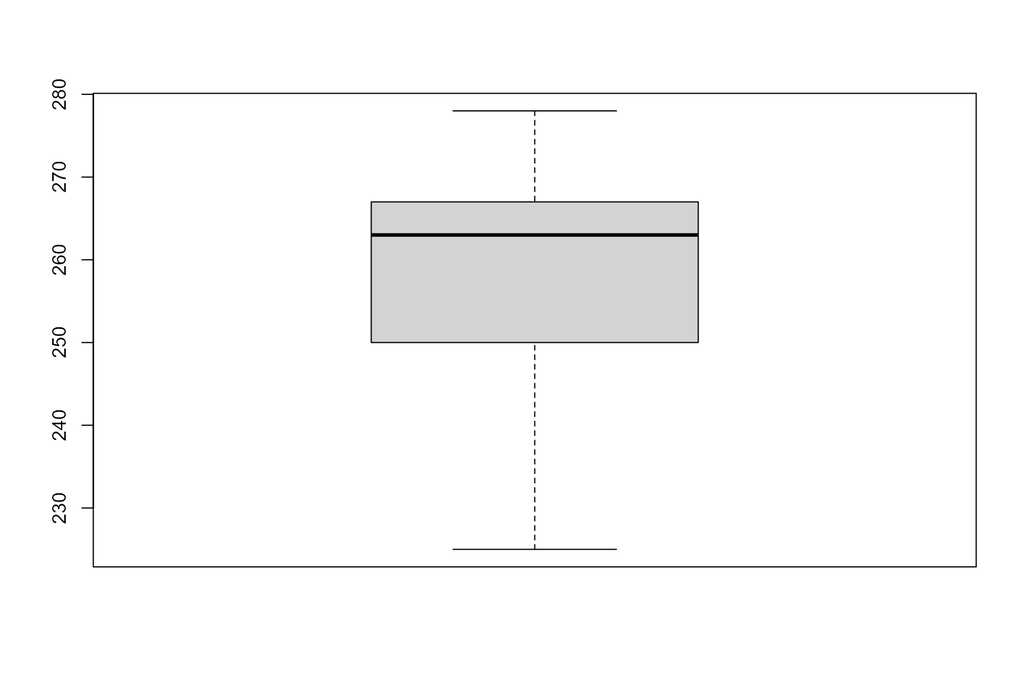

```r
boxplot(values(ras_bio_asc_01), na.rm = TRUE, outline = FALSE) ## outline = outliers
```

Similarly, we can look at the distribution of the values in each single layer of a raster stack.

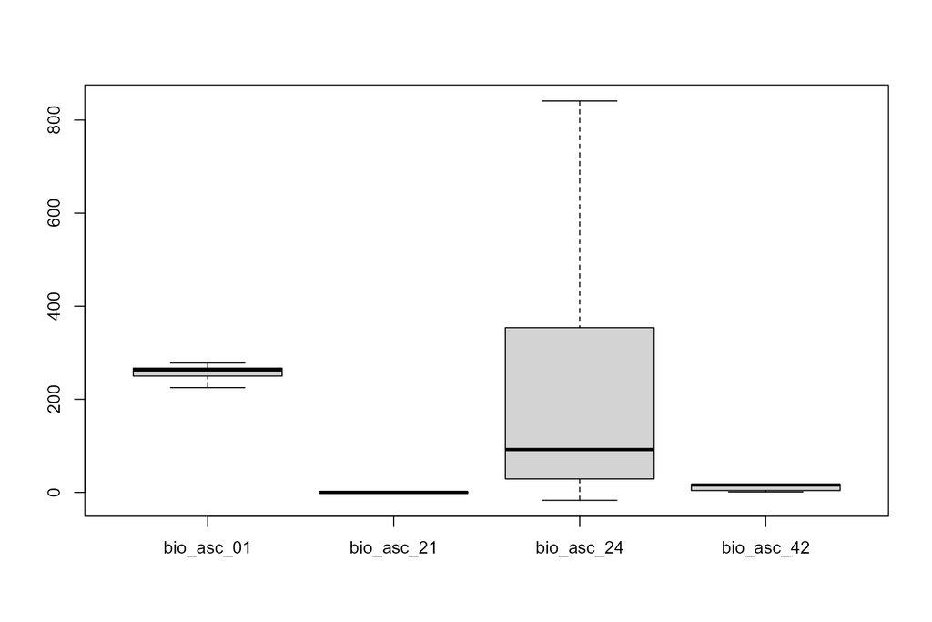

```r
boxplot(predictors, outline = FALSE)
```

Example: Find areas with mean annual temp above 25 degrees Celsius

```r
## first divide by 10 to get 'realistic' temperature ranges. Remember the values
## of the raster had integer values because this data type uses less computer memory
## than a floating-point number (meaning numbers with digits)

mean.t.c <- ras_bio_asc_01 / 10
range(values(mean.t.c), na.rm = TRUE)
```

```
## [1]  6.3 27.8
```

```r
## now ask which ones are above 25 degrees Celsius
mean.t.c.25 <- mean.t.c >= 25
mean.t.c.25 ## check the values -> binary!
```

```
## class       : SpatRaster
## size        : 1425, 1423, 1  (nrow, ncol, nlyr)
## resolution  : 0.008333334, 0.008333334  (x, y)
## extent      : 108.3341, 120.1925, -4.374013, 7.500988  (xmin, xmax, ymin, ymax)
## coord. ref. : lon/lat WGS 84
## source(s)   : memory
## varname     : bio_asc_01
## name        : bio_asc_01
## min value   :      FALSE
## max value   :       TRUE
```

Have a look at the result using a binary plot, i.e.all areas where the temperature is above 25 degrees (TRUE) are plotted:

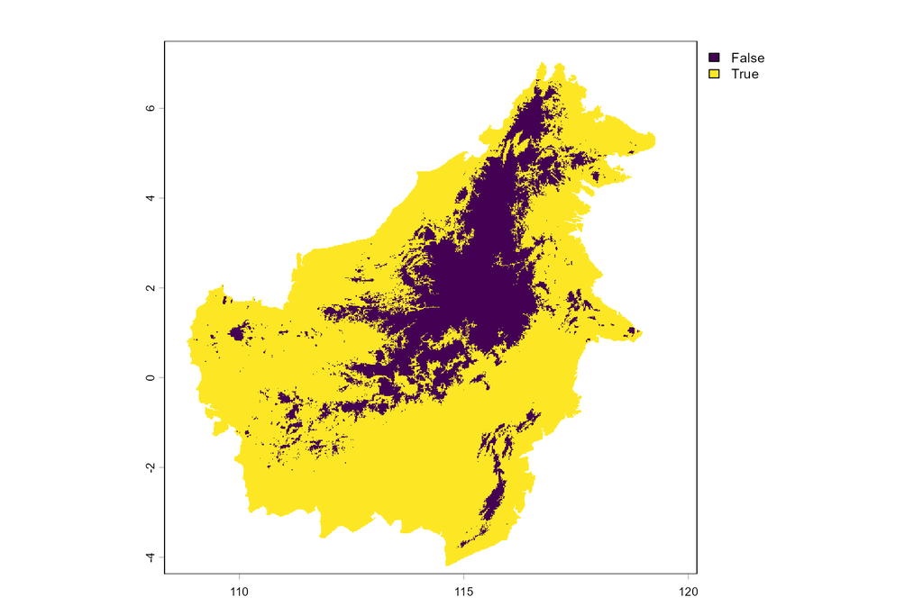

```r
plot(x = mean.t.c.25)
```

```r
range(values(mean.t.c.25), na.rm =TRUE)
```

```
## [1] 0 1
```

Retrieve metrics/ statistics from the `SpatRaster` objects with function `global()`:

```r
round(x = global(x = predictors, stat = 'mean', na.rm = TRUE), digits = 2)
```

```
##              mean
## bio_asc_01 255.61
## bio_asc_21   0.02
## bio_asc_24 251.75
## bio_asc_42  10.65
```

**Optional - pretty violin plots in ggplot2**

With the help of the `{rasVis}` package we can plot violin charts `bwplot()` to visualize the summary statistics of a raster across all raster cells:

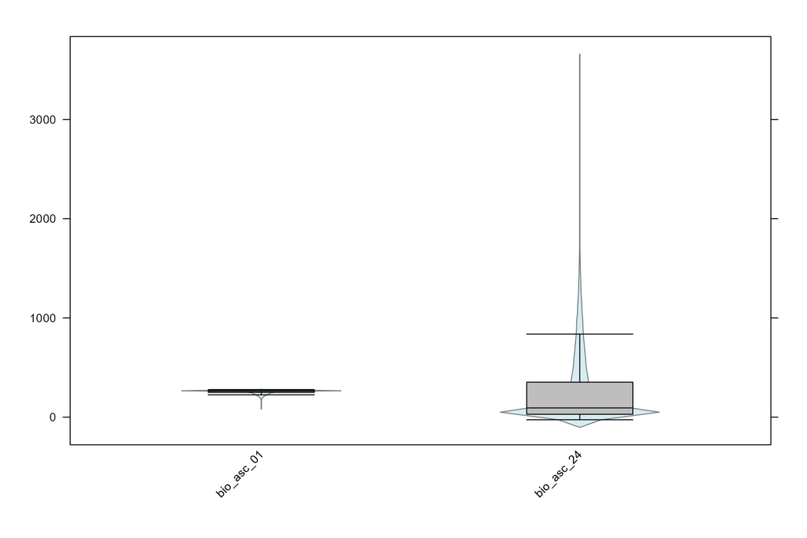

```r
rasterVis::bwplot(x = predictors[[c(1, 3)]])
```

```r
## n.b. double [[ ]] because stack is a list of spatial rasters
```

However, these plots are not really pretty. More beautiful violin plots can be found in ggplot2. For this, we need to transform the `SpatRaster` data into a data.frame first:

```r
## first omit NA values (which represent the ocean around Borneo)
raster_df <- na.omit(data.frame(values(predictors[[c(1,3)]])))

raster_names <- names(raster_df)
raster_ct    <- dim(raster_df)[1]
df2 <- data.frame(val = c(raster_df[,names(raster_df)[1]],
                          raster_df[,names(raster_df)[2]]))
df2$grp <- rep(raster_names , each = raster_ct)
head(df2)
```

```
##   val        grp
## 1 271 bio_asc_01
## 2 271 bio_asc_01
## 3 270 bio_asc_01
## 4 270 bio_asc_01
## 5 270 bio_asc_01
## 6 270 bio_asc_01
```

```r
## take a random subsample of the data to not crash your PC when plotting:
a <- sample(x = nrow(df2), size = 1000, replace = FALSE)
df3 <- df2[a,]
```

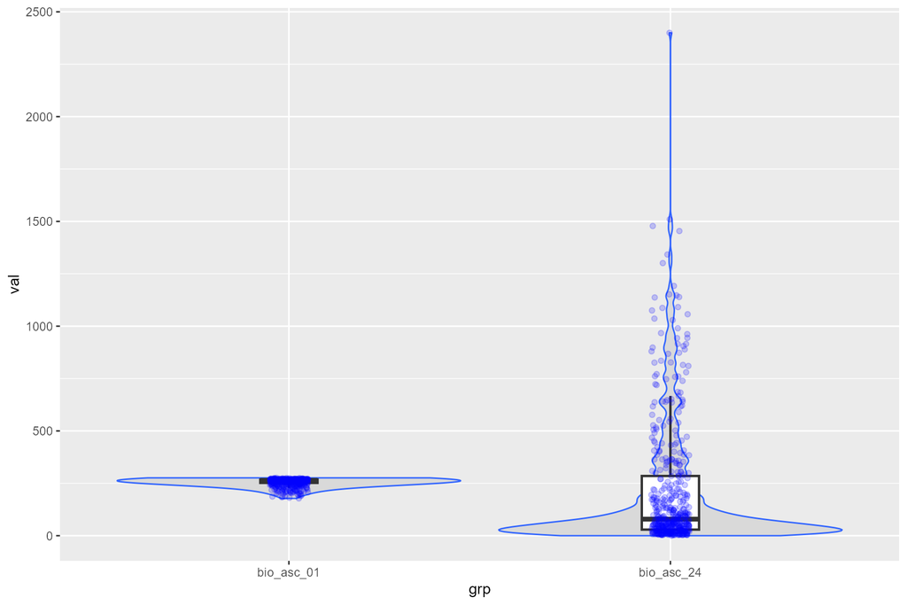

```r
## a violin-box plot combination with raw data strips
p <- ggplot(data = df3, aes(x = grp, y = val)) +
  geom_violin(scale = "width", fill = "grey85", color = "#3366FF", bw = 20) +
  geom_boxplot(width = 0.15, size = 0.8, outlier.color = NA) + ## remove outliers
  geom_jitter(height = 0, width = 0.05, alpha = 0.2, size = 1.5, color = 'blue')

p
```

Since the units are so different, it makes more sense in this case to plot them separately, using a `facet_wrap()` and `scales = free`.

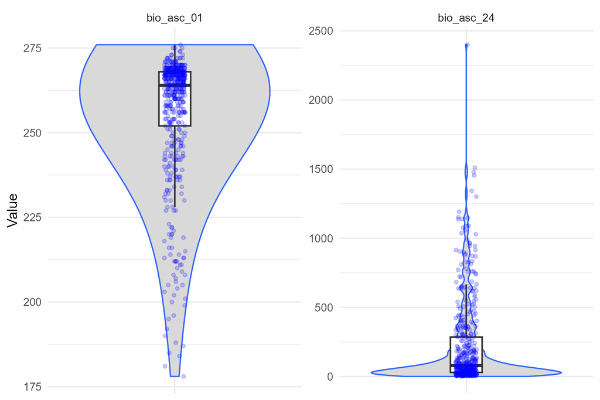

```r
p +
  facet_wrap(vars(grp), scales = "free") +
  scale_x_discrete(guide = "none")  + ## remove axis ticks and labels on x
  labs(x = NULL, y = "Value") +
  theme_minimal(base_size = 15) ## set custom plot style
```

```r
# save the last plot
ggsave(paste0(output_wd, "/savedggplot.pdf"), width = 5, height = 5, dpi = 600)
## or use here:
# ggsave(here("output", "savedggplot.pdf"), width = 5, height = 5, dpi = 600)
```

…or plot them separately and combine them using the [`{patchwork}` package](https://patchwork.data-imaginist.com/):

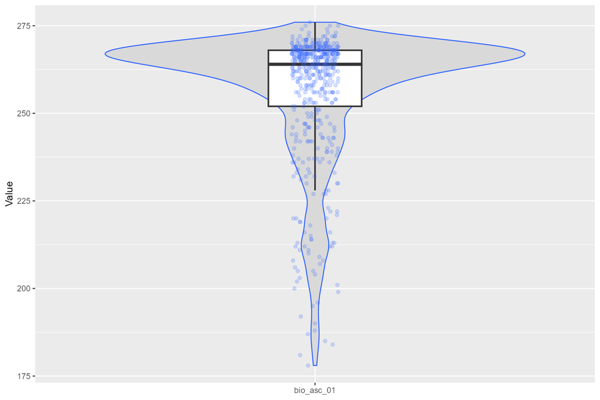

```r
df3_bio1 <- subset(df3, df3$grp == 'bio_asc_01')
df3_bio24 <- subset(df3, df3$grp == 'bio_asc_24')

p1 <- ggplot(data = df3_bio1, aes(x = grp, y = val)) +
      geom_violin(scale = "width", fill = "grey85", colour = "#3366FF") +
      geom_boxplot(width = 0.2, size = 0.8, outlier.color = NA) + ## remove outliers
      geom_jitter(height = 0, width = 0.05, alpha = 0.2, size = 1.5, colour = "#3366FF") +
      labs(x = NULL, y = "Value")

p2 <- ggplot(data = df3_bio24, aes(x = grp, y = val)) +
      geom_violin(scale = "width", fill = "grey85", colour = "#3366FF") +
      geom_boxplot(width = 0.2, size = 0.8, outlier.color = NA) + ## remove outliers
      geom_jitter(height = 0, width = 0.05, alpha = 0.2, size = 1.5, colour = "#3366FF") +
      labs(x = NULL, y = "")

p1
```

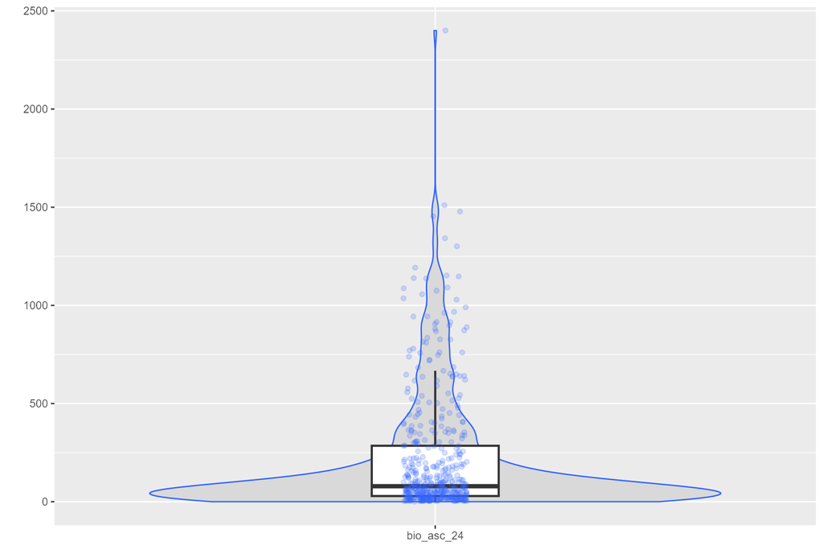

```r
p2
```

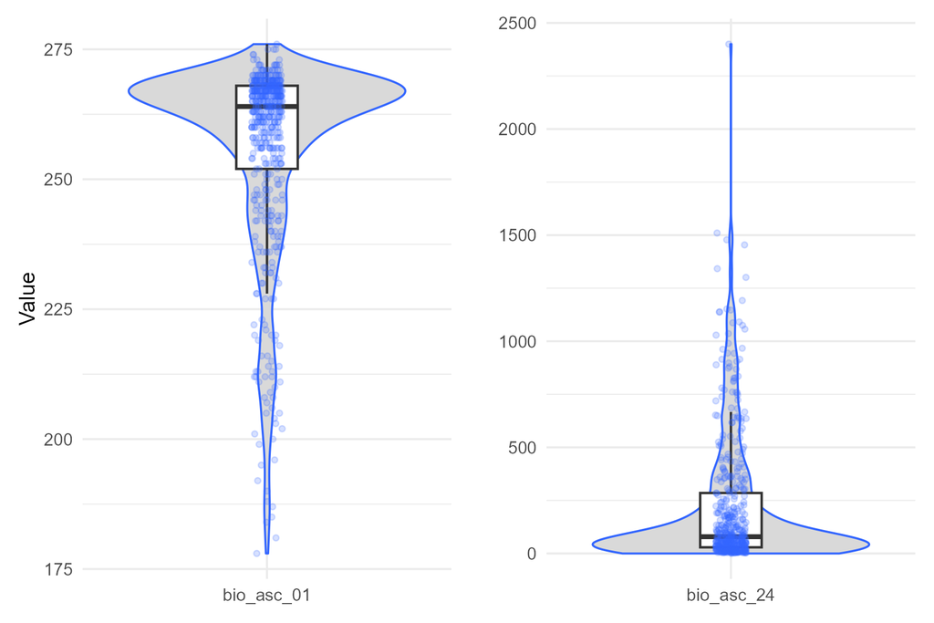

```r
## multipanel plot with {patchwork}
(p1 + p2) * theme_minimal(base_size = 15) ## apply custom style
```

check here for how `{ggplot2}` works if you want to make really nice plots: * https://ggplot2.tidyverse.org/

or get inspiration here:

- https://www.cedricscherer.com/2019/08/05/a-ggplot2-tutorial-for-beautiful-plotting-in-r/
- https://www.r-graph-gallery.com/

Back to spatial R!

### Accessing and changing single raster cell values

Remember the function **`extract()`** from the lecture. In the following, we extract from the small (cropped) raster the first three values (= cols 1-3; longitude or x-axis) at line 5 (= row 5; latitude or y-axis).

```r
cells <- cellFromRowCol(object = ras_bio_asc_01_cr, row = 5, col = 1:3)
cells    ## Note: returns cell ID number = the index / row number! Not the value!!!!
```

```
## [1] 121 122 123
```

```r
## returns cell values!:
extract(x = ras_bio_asc_01_cr, y = cells)
```

```
##   bio_asc_01
## 1        266
## 2        265
## 3        266
```

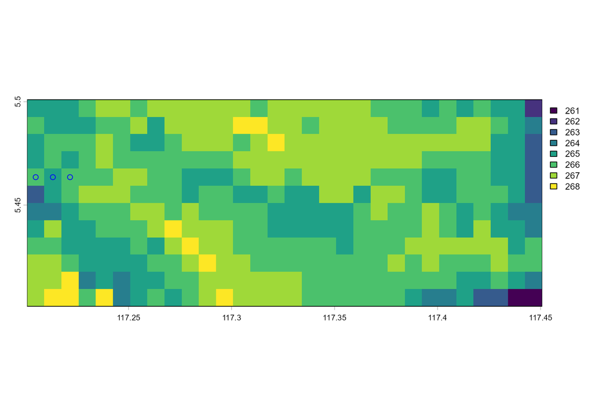

```r
## plot it:
plot(x = ras_bio_asc_01_cr)
## to plot the points on top, insert the 'cells' index into
## the data frame of the coordinates (crds) of the SpatRaster object ras_bio_asc_01_cr.
## Do you fully understand the following line?:
points(x = crds(ras_bio_asc_01_cr)[cells,], col = "blue")
```

Change raster values in an existing raster:

```r
## get the coordinates; cells was the object containing the index (i.e. the cell numbering)
## the function returns a matrix (it could have been easy...)
xy <- terra::xyFromCell(object = ras_bio_asc_01_cr, cell = cells) ## same as:
#xy <- terra::crds(ras_bio_asc_01_cr)[cells,]
xy
```

```
##             x        y
## [1,] 117.2050 5.463488
## [2,] 117.2133 5.463488
## [3,] 117.2216 5.463488
```

```r
class(xy)
```

```
## [1] "matrix" "array"
```

```r
extract(x = ras_bio_asc_01_cr, y = xy) ## direct access to the cell values, not the index
```

```
##   bio_asc_01
## 1        266
## 2        265
## 3        266
```

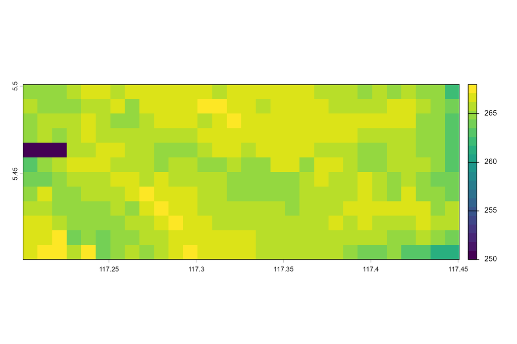

```r
## Change values of a raster, e.g. for adding forest or creating a corridor
## take care! -> irreversible! better work on a copy!
copy_ras <- ras_bio_asc_01_cr
copy_ras[cells] <- 250 # here we set all values in the raster at the position index cells to 250
plot(x = copy_ras, col = viridis(20))
```

**Optional - extract values from a stack**

Advantage of working with stacks: Extract raster values from all `SpatRaster` objects at once (raster stack). This is very important if you want to create your master table, i.e. based on the xy-coordinates of your species sightings (i.e. GPS point locations), you could extract the underlying values of all environmental predictors at that location in one go.

We do that for an area in the center of Borneo. For this, first get the row and column indices of the center of a large Borneo map, e.g. `ras_bio_asc_01`, and 5 x 5 cells in addition, i.e. a square with an area of 5 km x 5 km:

```r
## divide by 2 to get the center cell
center_x = floor(nrow(predictors) / 2) ## learn about the functions round(),
center_y = floor(ncol(predictors) / 2) ##                 ceiling(), floor()
center_x; center_y ## center coordinates of the Borneo maps
```

```
## [1] 712
```

```
## [1] 711
```

```r
## start from center cell and go 5 cells in x and y direction
## This should yield 25 cells
stack_cells <- terra::cellFromRowColCombine(
  object = ras_bio_asc_01,
  row = c(center_x:(center_x + 4)),
  col = c(center_y:(center_y + 4))
)

## check
#?cellFromRowColCombine
## to get an overview over all possible functions to get access to the raster

head(stack_cells) ## mind: these are index numbers! Not cell values!
```

```
## [1] 1012464 1012465 1012466 1012467 1012468 1013887
```

Why are these index numbers so large? Because the counting starts at the upper left corner of the map and continues consecutively, i.e. the data (`ras_bio_asc_01@data@values`) are one huge vector with length `nrow * ncol`!

Now, extract them with the useful function `èxtract()` into an object called ‘mastertable’ that you can for example use for statistical analyses in R:

```r
pred_dat <- extract(predictors, stack_cells)
head(pred_dat)
```

```
##   bio_asc_01  bio_asc_21 bio_asc_24 bio_asc_42
## 1        255 0.000000000        303          1
## 2        252 0.000000000        325          1
## 3        253 0.000000000        284          1
## 4        254 0.000000000        225          1
## 5        254 0.000000000        351          1
## 6        253 0.008333334        299          1
```

```r
## combine in one table that can be used for further statistical analysis
mastertable <- data.frame(stack_cells, pred_dat)
head(mastertable)
```

```
##   stack_cells bio_asc_01  bio_asc_21 bio_asc_24 bio_asc_42
## 1     1012464        255 0.000000000        303          1
## 2     1012465        252 0.000000000        325          1
## 3     1012466        253 0.000000000        284          1
## 4     1012467        254 0.000000000        225          1
## 5     1012468        254 0.000000000        351          1
## 6     1013887        253 0.008333334        299          1
```

End optional.

### Compute distance to points

From the three selected cells in the small raster ‘ras_bio_asc_01_cr’, we want to calculate the distance to each other cell in the raster.

```r
## remember from above: the object 'xy' was a matrix ## check #class(xy)
## turn first into SpatVector - this is the format needed for the distance() function below
## we do this just for 1 cell (point),
sv_xy <- terra::vect(xy)[1]
sv_xy
```

```
## class       : SpatVector
## geometry    : points
## dimensions  : 1, 0  (geometries, attributes)
## extent      : 117.205, 117.205, 5.463488, 5.463488  (xmin, xmax, ymin, ymax)
## coord. ref. :
```

Check the object `sv_xy`: since `xy` was a simple matrix and not a spatial object, there is no crs assigned. The slot for ‘coord.ref.’ is empty. That means, we now have to first assign the CRS so that the following functions know where exactly the different layers are on earth.

```r
crs(sv_xy) <- "epsg:4326"

## check:
sv_xy
```

```
## class       : SpatVector
## geometry    : points
## dimensions  : 1, 0  (geometries, attributes)
## extent      : 117.205, 117.205, 5.463488, 5.463488  (xmin, xmax, ymin, ymax)
## coord. ref. : lon/lat WGS 84 (EPSG:4326)
```

```r
## Nice!
```

Now the CRS is set/ assigned and we can continue with distance calculations:

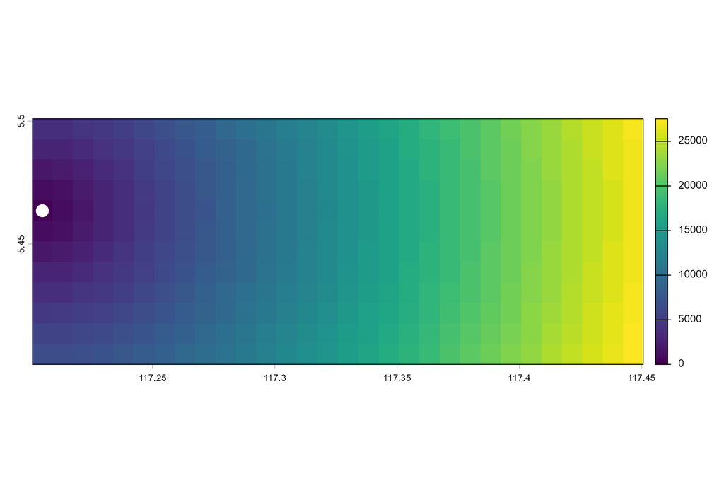

```r
## calculate distance
my_dist <- distance(x = ras_bio_asc_01_cr, y = sv_xy)
plot(x = my_dist) ## units?
points(sv_xy, col= 'white', pch= 19, cex = 2)
```

Calculate distance from many points:

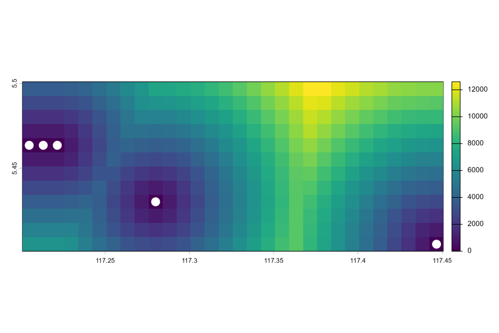

```r
cells1 <- c(cells, 250, 360) ## add  more randomly chosen points to cells = cells1
sv_xy_2 <- vect(xyFromCell(ras_bio_asc_01_cr, cells1)) ## we create a new spatVect
crs(sv_xy_2) <- "epsg:4326" ## same procedure as above
my_dist <- distance(x = ras_bio_asc_01_cr, y = sv_xy_2)

# viz
plot(my_dist) #units?
points(sv_xy_2, col= 'white', pch= 19, cex = 2)
```

## Categorical rasters

Let’s go back to our raster with the temperature below or above 25° C. It is a binary map with categories (above or below 25°C), although hard-coded via the numbers 0 and 1. This can be transformed into a factors:

```r
mean_f_ras <- as.factor(mean.t.c.25)
levels(mean_f_ras)
```

```
## [[1]]
##   ID bio_asc_01
## 1  0          0
## 2  1          1
```

```r
## create a level look-up table
cls <- data.frame(ID=0:1, mean_t = c("below","above"))
levels(mean_f_ras) <- cls
is.factor(mean_f_ras)
```

```
## [1] TRUE
```

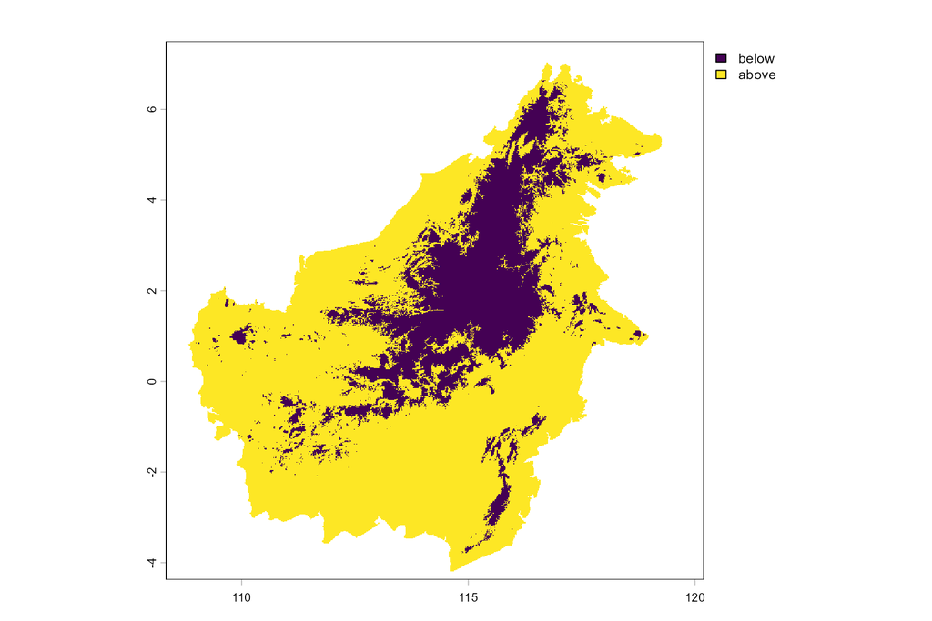

```r
plot(x=mean_f_ras)
```

In the same way, a legend e.g. for several land use categories could be defined.

### Quantifying landscape heterogeneity

See separate course. Possible with package `landscapemetrics`: https://r-spatialecology.github.io/landscapemetrics/ based on FRAGSTATS: https://www.fragstats.org/

For example, calculate the Shannon diversity index:

```r
#install.packages('landscapemetrics')
#library(landscapemetrics)
#check_landscape(mean_f_ras) ## by now, you understand what the error message means....
#mean_f_ras_proj <- terra::project(mean_f_ras, 'EPSG:3085')

#check_landscape(mean_f_ras_proj) ## check again
#lsm_l_shdi(mean_f_ras_proj) ## 0.6

## simply do it by hand
#terra::summary(mean_f_ras_proj) ## take out the values
#n <- c(7017,21712)
#p <- n / sum(n)

## Shannon
#H <- -sum(p * log(p))
#H ## 0.6
```

## Data export - saving raster data

Save the raster (not the plot…): There are many exchange formats for rasters. The best choice is considered to be GeoTiff, which also saves the projection and is smaller than ascii. However, for modelling e.g. in MaxEnt, the raster maps are needed in ascii-format. Also, ascii type files can be opened easily in any text editor. Try this with the small cropped raster.

```r
## save the small cropped and aggregated rasters
terra::writeRaster(x = ras_bio_asc_01_cr,
            filename = paste0(output_wd,"/bor_crop.asc"),
            # or use here(): here("output", "bor_crop.asc")
            overwrite = TRUE,
            NAflag = -9999)


terra::writeRaster(x = ras_bio_asc_01_agg,
            filename = paste0(output_wd,"/ras_bio_asc_01_agg.asc"),
            # or use here(): here("output", "ras_bio_asc_01_agg.asc")
            overwrite = TRUE,
            NAflag = -9999)
```

# Vector data / shapefiles

## Import shapefiles

Currently, there are two packages *sp* and *sf* (standing for simple features), both with still important functionality. However, sf is much easier to use and handle. The suggestion currently is: [learn both!](https://www.r-bloggers.com/2018/03/should-i-learn-sf-or-sp-for-spatial-r-programming/)

In the following, the most important commands are provided for the sf-package, and if necessary, also for the sp-package. We start with loading an ESRI shapefile.

```r
## Border of countries and provinces of Borneo
## vecs_wd is the folder where vector data are stored
## - only loading columns 1:3, 5, 7, 17, 18 of its attribute table (a. t.):
Borneo_shp <- sf::st_read(dsn = vecs_wd, layer = "borneo_admin")[, c(1:3, 5, 7, 17, 18)]
## Protected Areas (National Parks, Nature Reserves, Forest Reserves)
PA_shp     <-  st_read(dsn = vecs_wd,
                       layer = "Bor_PA")[, c(1:4)]
## fix problematic polygons
PA_shp <- st_make_valid(PA_shp)

## main rivers
River_shp  <- st_read(dsn = vecs_wd, layer = "sn_100000")
## admin areas
Admin_shp <- st_read(dsn = vecs_wd, layer = "borneo_admin")[,c(1:3,5,7,17,18)]
```

More here: - https://cran.r-project.org/web/packages/sf/vignettes/sf1.html

### Transformations between simple feature `{sf}` and SpatialPolygonsDataFrame `{sp}`

Since some functions are still only available in the `{sp}` package, it can be helpful to remember how to back and forth-transform between the data types.

```r
## transformations
Admin_sp <- as(Admin_shp, "Spatial") ## from sf to sp object
Admin_sf <- as(Admin_sp, "sf")       ## from sp object to sf object
```

## Import spatial points

In the following, we load two point data-sets of different species locations.

```r
pt_shp <- st_read(dsn = paste0(anim_wd, "/FCsim.shp")) ## CRS is missing!
head(pt_shp)  ## attribute table with geometry column
```

```
## Simple feature collection with 6 features and 3 fields
## Geometry type: POINT
## Dimension:     XY
## Bounding box:  xmin: 117.4704 ymin: 5.005603 xmax: 118.4117 ymax: 5.381088
## CRS:           NA
##   Id  POINT_X  POINT_Y                  geometry
## 1  0 118.4117 5.221667 POINT (118.4117 5.221667)
## 2  0 118.2645 5.005603 POINT (118.2645 5.005603)
## 3  0 117.7992 5.029167 POINT (117.7992 5.029167)
## 4  0 117.6058 5.177957 POINT (117.6058 5.177957)
## 5  0 117.5566 5.381088 POINT (117.5566 5.381088)
## 6  0 117.4704 5.005603 POINT (117.4704 5.005603)
```

```r
st_crs(pt_shp) <- 4326 ## set it with command st_crs()
pt_shp
```

```
## Simple feature collection with 55 features and 3 fields
## Geometry type: POINT
## Dimension:     XY
## Bounding box:  xmin: 109.3758 ymin: -2.744159 xmax: 118.4117 ymax: 5.824283
## Geodetic CRS:  WGS 84
## First 10 features:
##    Id  POINT_X  POINT_Y                  geometry
## 1   0 118.4117 5.221667 POINT (118.4117 5.221667)
## 2   0 118.2645 5.005603 POINT (118.2645 5.005603)
## 3   0 117.7992 5.029167 POINT (117.7992 5.029167)
## 4   0 117.6058 5.177957 POINT (117.6058 5.177957)
## 5   0 117.5566 5.381088 POINT (117.5566 5.381088)
## 6   0 117.4704 5.005603 POINT (117.4704 5.005603)
## 7   0 117.2734 5.227201 POINT (117.2734 5.227201)
## 8   0 116.7256 5.319533 POINT (116.7256 5.319533)
## 9   0 116.6467 5.162500   POINT (116.6467 5.1625)
## 10  0 117.2475 4.888333 POINT (117.2475 4.888333)
```

Spatial points are defined by two columns with x and y coordinates; they can be imported as normal `data.frames` and then converted to spatial objects:

```r
## read the data.frame
pt_file <- paste0(anim_wd, "/MyNewSpecies.csv")
df_recs <- read.table(file = pt_file, header = TRUE, sep = ',') # animal records
head(df_recs)
```

```
##   species     long         lat
## 1 mysimsp 109.4716 -1.11984615
## 2 mysimsp 109.3216 -0.02817942
## 3 mysimsp 117.0383  3.60515411
## 4 mysimsp 109.1550  0.09682059
## 5 mysimsp 111.1550  1.78848735
## 6 mysimsp 115.4550  4.93848752
```

```r
class(x = df_recs)
```

```
## [1] "data.frame"
```

```r
head(x = df_recs)
```

```
##   species     long         lat
## 1 mysimsp 109.4716 -1.11984615
## 2 mysimsp 109.3216 -0.02817942
## 3 mysimsp 117.0383  3.60515411
## 4 mysimsp 109.1550  0.09682059
## 5 mysimsp 111.1550  1.78848735
## 6 mysimsp 115.4550  4.93848752
```

This is still a `data.frame`, not yet a spatial object. See below of how to convert a data.frame into a spatial `{sf}` object. You need to give the columns of your file that contain the x and y coordinates, and you need to set the CRS.

```r
recs_sf <- st_as_sf(x = data.frame(df_recs),
                    coords = c(x="long", y="lat"),
                    crs = 4326,
                    sf_column_name = "geometry")
```

## Working with vector data

Explore the objects and retrievable information:

```r
str(object = PA_shp) ## shows which slot can be addressed with $
```

```
## Classes 'sf' and 'data.frame':   255 obs. of  5 variables:
##  $ SITE_ID : int  785 787 791 795 1300 783 784 786 788 789 ...
##  $ NAME_ENG: chr  "Kinabalu" "Mulu" "Niah" "Tawau Hill Park" ...
##  $ COUNTRY : chr  "Malaysia" "Malaysia" "Malaysia" "Malaysia" ...
##  $ SUB_NAT : chr  "Sabah" "Sarawak" "Sarawak" "Sabah" ...
##  $ geometry:sfc_MULTIPOLYGON of length 255; first list element: List of 1
##   ..$ :List of 1
##   .. ..$ : num [1:322, 1:2] 117 117 117 117 117 ...
##   ..- attr(*, "class")= chr [1:3] "XY" "MULTIPOLYGON" "sfg"
##  - attr(*, "sf_column")= chr "geometry"
##  - attr(*, "agr")= Factor w/ 3 levels "constant","aggregate",..: NA NA NA NA
##   ..- attr(*, "names")= chr [1:4] "SITE_ID" "NAME_ENG" "COUNTRY" "SUB_NAT"
```

```r
attributes(x = PA_shp) ## similar to above
```

```
## $names
## [1] "SITE_ID"  "NAME_ENG" "COUNTRY"  "SUB_NAT"  "geometry"
##
## $row.names
##   [1]   1   2   3   4   5   6   7   8   9  10  11  12  13  14  15  16  17  18
##  [19]  19  20  21  22  23  24  25  26  27  28  29  30  31  32  33  34  35  36
##  [37]  37  38  39  40  41  42  43  44  45  46  47  48  49  50  51  52  53  54
##  [55]  55  56  57  58  59  60  61  62  63  64  65  66  67  68  69  70  71  72
##  [73]  73  74  75  76  77  78  79  80  81  82  83  84  85  86  87  88  89  90
##  [91]  91  92  93  94  95  96  97  98  99 100 101 102 103 104 105 106 107 108
## [109] 109 110 111 112 113 114 115 116 117 118 119 120 121 122 123 124 125 126
## [127] 127 128 129 130 131 132 133 134 135 136 137 138 139 140 141 142 143 144
## [145] 145 146 147 148 149 150 151 152 153 154 155 156 157 158 159 160 161 162
## [163] 163 164 165 166 167 168 169 170 171 172 173 174 175 176 177 178 179 180
## [181] 181 182 183 184 185 186 187 188 189 190 191 192 193 194 195 196 197 198
## [199] 199 200 201 202 203 204 205 206 207 208 209 210 211 212 213 214 215 216
## [217] 217 218 219 220 221 222 223 224 225 226 227 228 229 230 231 232 233 234
## [235] 235 236 237 238 239 240 241 242 243 244 245 246 247 248 249 250 251 252
## [253] 253 254 255
##
## $sf_column
## [1] "geometry"
##
## $agr
##  SITE_ID NAME_ENG  COUNTRY  SUB_NAT
##     <NA>     <NA>     <NA>     <NA>
## Levels: constant aggregate identity
##
## $class
## [1] "sf"         "data.frame"
```

Accessing simple feature objects — easy handling, similar to `data.frames`:

```r
## Please note the similarity to accessing info from rasters.
ext(PA_shp) ## extent
```

```
## SpatExtent : 108.59686960000001, 119.61760969999999, -4.1835602999999999, 9.9112286999999988 (xmin, xmax, ymin, ymax)
```

```r
xmin(ext(PA_shp))
```

```
## [1] 108.5969
```

```r
names(x = PA_shp) ## returns column names of a.t.
```

```
## [1] "SITE_ID"  "NAME_ENG" "COUNTRY"  "SUB_NAT"  "geometry"
```

Summarizing spatial information for each column of attribute table [a.t.]:

```r
summary(object = PA_shp)
```

```
##     SITE_ID            NAME_ENG        COUNTRY         SUB_NAT
##  Min.   :   783   Length   :255   Length   :255   Length   :255
##  1st Qu.:  3844   N.unique :248   N.unique :  4   N.unique :  4
##  Median :  9842   N.blank  :  0   N.blank  :  0   N.blank  :  0
##  Mean   : 45309   Min.nchar:  4   Min.nchar:  8   Min.nchar:  5
##  3rd Qu.: 19582   Max.nchar: 42   Max.nchar: 17   Max.nchar: 10
##  Max.   :901238                                   NAs      : 64
##           geometry
##  MULTIPOLYGON :255
##  epsg:4326    :  0
##  +proj=long...:  0
##
##
##
```

Have a look at the content of the attribute table. It looks like a `data.frame`, but has the geometry stored as last column (recap from the introductory lecture).

```r
head(x = PA_shp)  ## first 6 lines
```

```
## Simple feature collection with 6 features and 4 fields
## Geometry type: MULTIPOLYGON
## Dimension:     XY
## Bounding box:  xmin: 111.8754 ymin: 1.32105 xmax: 118.7899 ymax: 6.4952
## Geodetic CRS:  WGS 84
##   SITE_ID        NAME_ENG  COUNTRY SUB_NAT                       geometry
## 1     785        Kinabalu Malaysia   Sabah MULTIPOLYGON (((116.5979 6....
## 2     787            Mulu Malaysia Sarawak MULTIPOLYGON (((114.9033 4....
## 3     791            Niah Malaysia Sarawak MULTIPOLYGON (((113.7986 3....
## 4     795 Tawau Hill Park Malaysia   Sabah MULTIPOLYGON (((117.8497 4....
## 5    1300  Lanjak-Entimau Malaysia Sarawak MULTIPOLYGON (((112.2054 1....
## 6     783        Semporna Malaysia   Sabah MULTIPOLYGON (((118.7796 4....
```

```r
#tail(x = PA_shp) ## last 6 lines
```

Retrieving information of a.t. — recap working with `data.frames` from `Day1_R-Intro` course.

```r
PA_shp[1, ] ## returns first entry (row) of all 4 columns
```

```
## Simple feature collection with 1 feature and 4 fields
## Geometry type: MULTIPOLYGON
## Dimension:     XY
## Bounding box:  xmin: 116.4638 ymin: 5.99952 xmax: 116.7631 ymax: 6.4952
## Geodetic CRS:  WGS 84
##   SITE_ID NAME_ENG  COUNTRY SUB_NAT                       geometry
## 1     785 Kinabalu Malaysia   Sabah MULTIPOLYGON (((116.5979 6....
```

```r
PA_shp[, 2] ## returns content of column 2 only!
```

```
## Simple feature collection with 255 features and 1 field
## Geometry type: MULTIPOLYGON
## Dimension:     XY
## Bounding box:  xmin: 108.5969 ymin: -4.18356 xmax: 119.6176 ymax: 9.911229
## Geodetic CRS:  WGS 84
## First 10 features:
##           NAME_ENG                       geometry
## 1         Kinabalu MULTIPOLYGON (((116.5979 6....
## 2             Mulu MULTIPOLYGON (((114.9033 4....
## 3             Niah MULTIPOLYGON (((113.7986 3....
## 4  Tawau Hill Park MULTIPOLYGON (((117.8497 4....
## 5   Lanjak-Entimau MULTIPOLYGON (((112.2054 1....
## 6         Semporna MULTIPOLYGON (((118.7796 4....
## 7         Samunsam MULTIPOLYGON (((109.6615 1....
## 8        Similajau MULTIPOLYGON (((113.1826 3....
## 9            Klias MULTIPOLYGON (((115.636 5.3...
## 10      Pulau Tiga MULTIPOLYGON (((115.6796 5....
```

```r
## PA_shp$NAME_ENG ## returns a long list
head(x = PA_shp$NAME_ENG)
```

```
## [1] "Kinabalu"        "Mulu"            "Niah"            "Tawau Hill Park"
## [5] "Lanjak-Entimau"  "Semporna"
```

```r
## using head() to only show the first 6 entries only of column 'NAME_ENG'
```

```r
PA_shp[1, 1] ## = PA_shp$SITE_ID[1]
```

```
## Simple feature collection with 1 feature and 1 field
## Geometry type: MULTIPOLYGON
## Dimension:     XY
## Bounding box:  xmin: 116.4638 ymin: 5.99952 xmax: 116.7631 ymax: 6.4952
## Geodetic CRS:  WGS 84
##   SITE_ID                       geometry
## 1     785 MULTIPOLYGON (((116.5979 6....
```

```r
PA_shp[2, 3] ## = PA_shp$COUNTRY[2]
```

```
## Simple feature collection with 1 feature and 1 field
## Geometry type: MULTIPOLYGON
## Dimension:     XY
## Bounding box:  xmin: 114.7777 ymin: 3.9186 xmax: 114.9945 ymax: 4.28586
## Geodetic CRS:  WGS 84
##    COUNTRY                       geometry
## 2 Malaysia MULTIPOLYGON (((114.9033 4....
```

The following returns the row indices of the data frame or a.t., respectively:

```r
which(x = PA_shp$COUNTRY == 'Malaysia')
```

```
##   [1]   1   2   3   4   5   6   7   8   9  10  11  12  13  26  27  28  29  30
##  [19]  31  32  33  34  35  36  37  38  39  40  41  42  43  44  45  46  47  48
##  [37]  49  50  51  52  53  54  55  56  63  64  65  66  67  68  69  70  71  72
##  [55]  73  74  75  76  77  80  81 101 102 103 104 113 114 115 116 117 118 119
##  [73] 120 121 122 123 124 125 126 127 128 129 130 131 132 133 134 135 136 137
##  [91] 138 139 140 141 142 143 144 145 146 147 148 149 150 151 152 153 154 155
## [109] 156 157 158 159 161 162 163 164 165 166 167 169 170 171 172 185 186 187
## [127] 190 191 192 193 194 195 196 221 222 223 224 225 226 227 228 230 233 237
## [145] 238 239 240 241 249 250 251 254 255
```